# Borgerpanel conjoint-eksperimenter

Sveinung Arnesen

1/6/2021

```r
d <- read_sav("C:/Users/svein/Documents/DemovateR/Surveys/Data/responsanalyse.SAV")
d <- tibble(d, stringsAsFactors = FALSE)
e <- read_sav("C:/Users/svein/Documents/DemovateR/Surveys/Data/responsanalyse.SAV")

#Import variables from larger data set, and saving the relevant variables as RData file (commented out)
#d2 <- read_sav('C:/Users/svein/Documents/DemovateR/Surveys/Data/Norsk medborgerpanel - runde 18 - v-101.sav') %>% select(starts_with('r18padproleg')) %>% filter(!is.na(r18padprolegran))
#d2 <- tibble(d2, stringsAsFactors = FALSE)
#save(d2, file = 'Data/r18padproleg.RData')

load(file = 'Data/r18padproleg.RData')
d2 <- na_if(d2, c(97:98))
```

# 1 Byborgerpanel - demokratisurvey i Bergen 2020

## 1.1 Deltakelse

Respondentene ble bedt om å ta stilling til dette scenariet:

Bergen kommune har bestemt seg for å gjennomføre såkalte borgerpaneler i tiden framover. Dette er en ordning hvor en gruppe innbyggere i kommunen blir invitert til å diskutere og gjøre seg opp en mening om en politisk sak. Jeg skal lese opp noen måter dette borgerpanelet kan gjennomføres på, og vil gjerne vite hvor sannsynlig det er at du ville ha deltatt om det ble gjennomført slik jeg beskriver:

Borgerpanelet består av *|Deltakerantall* deltakere, finner sted i Bergen sentrum på en *|Dag*, og varer i 7 timer. Deltakerne blir *|Kompensasjon* for å være med. *|Rekrutteringsform* Saken som skal diskuteres er *|Sak*. Deltakerne bestemmer seg ut fra *|Beslutningsgrunnlag*. Deltakerne stemmer så over saken, og resultatet blir formidlet til kommunens politikere. *|Offentliggjøring*.

Hvor mange prosents sannsynlighet er det for at du ville ha deltatt i et slikt borgerpanel?

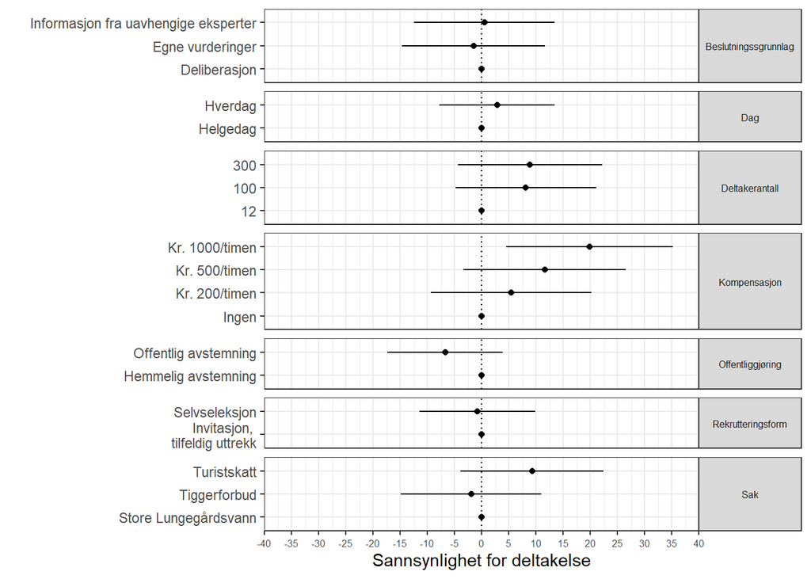

```r
source("C:/Users/svein/Documents/DemovateR/Surveys/amce.R")

main_01 <-  d %>% select(IntervjuID,
                         starts_with('R1DEMOVATE6') & ends_with('1')) %>%
  rename_at(vars(ends_with("1")),
            funs(str_replace(., "R1", ""))) %>%
  rename_at(vars(ends_with("1")),
                                 funs(str_replace(., "1", "")))
main_02 <-  d %>% select(IntervjuID,
                         starts_with('R1DEMOVATE6') & ends_with('2'))  %>%
  rename_at(vars(ends_with("2")),
            funs(str_replace(., "R1", ""))) %>%
  rename_at(vars(ends_with("2")),
                                 funs(str_replace(., "2", "")))
main_03 <-  d %>% select(IntervjuID,
                         starts_with('R1DEMOVATE6') & ends_with('3'))   %>%
  rename_at(vars(ends_with("3")),
            funs(str_replace(., "R1", ""))) %>%
  rename_at(vars(ends_with("3")),
                                 funs(str_replace(., "3", "")))

main <- bind_rows(main_01, main_02, main_03)

main <- main %>% mutate(DEMOVATE6_Antall = case_when(DEMOVATE6_Antall == 1 ~ '12',
                                                     DEMOVATE6_Antall == 2 ~ '100',
                                                     DEMOVATE6_Antall == 3 ~ '300',),
                        DEMOVATE6_Antall = lvls_reorder(DEMOVATE6_Antall, c(2,1,3)),
                        DEMOVATE6_Dag = case_when(DEMOVATE6_Dag == 1 ~ 'Hverdag',
                                                  DEMOVATE6_Dag == 2 ~ 'Helgedag'),
                        DEMOVATE6_Rekr = case_when(DEMOVATE6_Rekr == 1 ~ 'Selvseleksjon',
                                                   DEMOVATE6_Rekr == 2 ~ 'Invitasjon, \n tilfeldig uttrekk'),
                        DEMOVATE6_Komp = case_when(DEMOVATE6_Komp== 1 ~ 'Ingen',
                                                   DEMOVATE6_Komp == 2 ~ 'Kr. 200/timen',
                                                   DEMOVATE6_Komp == 3 ~ 'Kr. 500/timen',
                                                   DEMOVATE6_Komp == 4 ~ 'Kr. 1000/timen'),
                        DEMOVATE6_Komp = lvls_reorder(DEMOVATE6_Komp, c(1, 3, 4, 2)),
                        DEMOVATE6_Sak = case_when(DEMOVATE6_Sak == 1 ~ 'Store Lungegårdsvann',
                                                  DEMOVATE6_Sak == 2 ~ 'Tiggerforbud',
                                                  DEMOVATE6_Sak == 3 ~ 'Turistskatt'),
                        DEMOVATE6_Grunnlag = case_when(DEMOVATE6_Grunnlag == 1 ~ 'Egne vurderinger',
                                                       DEMOVATE6_Grunnlag == 2 ~ 'Informasjon fra uavhengige eksperter',
                                                       DEMOVATE6_Grunnlag == 3 ~ 'Deliberasjon'),
                        DEMOVATE6_Offentlig = case_when(DEMOVATE6_Offentlig == 1 ~ 'Offentlig avstemning',
                                                        DEMOVATE6_Offentlig == 2 ~ 'Hemmelig avstemning')
                        )

res_main <-  main %>%
  amce(DEMOVATE6_, DEMOVATE6_Antall, DEMOVATE6_Dag, DEMOVATE6_Rekr, DEMOVATE6_Komp, DEMOVATE6_Sak, DEMOVATE6_Grunnlag, DEMOVATE6_Offentlig)

res_main <- res_main %>%
  mutate(
  treatment =  case_when(treatment == "DEMOVATE6_Antall" ~ "Deltakerantall",
            treatment == "DEMOVATE6_Dag" ~ "Dag",
            treatment == "DEMOVATE6_Rekr" ~ "Rekrutteringsform",
            treatment == "DEMOVATE6_Komp" ~ "Kompensasjon",
            treatment == "DEMOVATE6_Sak" ~ "Sak",
            treatment == "DEMOVATE6_Grunnlag" ~ "Beslutningssgrunnlag",
            treatment == "DEMOVATE6_Offentlig" ~ "Offentliggjøring"))

fig_amce <-
  res_main %>%
  ggplot(aes(x = estimate, y = value)) +
  facet_grid(
    treatment ~ .,
    scales = "free_y",
    space = "free_y") +
  geom_errorbarh(
    aes(xmin = estimate - (2 * std_error),
        xmax = estimate + (2 * std_error)),
    height = 0) +
  geom_point() +
  geom_vline(aes(xintercept = 0), linetype = "dotted") +
  scale_x_continuous(
    limits = c(-40, 40),
    breaks = round(seq(-40, 40, 5), 5),
    expand = c(0, 0)) +
    labs(
    x = "Sannsynlighet for deltakelse",
    y = "") +
  theme_bw() +
  theme(plot.margin = unit(c(2, 2, 2, 2), "mm"),  plot.title = element_text(size=9), plot.subtitle = element_text(size=8), strip.text.y = element_text(size=6, angle=0) ,      axis.text.x=element_text(size=rel(0.7)))
fig_amce
```

Resultatene fra eksperimentet viser at respondentene blir mer positive til å delta hvis de får en økonomisk kompensasjon. Imidlertid må denne være veldig høy før deltakelsen blir signifikant høyere.

For øvrig er det ingen statistisk signifikante effekter, men likevel noen tendenser i utvalget som er verdt å merke seg. Det spiller i følge respondentene ingen rolle om borgerpanelet arrangeres på en hverdag eller helg, eller om man kan melde seg på selv eller ikke. Turistskatt virker å være en foretrukket sak over de to andre alternativene som var med i eksperimentet.

Til sist er respondentene mindre tilbøyelig til å delta dersom deres holdninger blir offentliggjort. Dette er interessant i sammenlikning med det neste eksperimentet, som måler legimititeten til borgerpanelet. Der er det nemlig motsatt, slik at respondentene mener at et borgerpanel som offentliggjør deltakernes holdninger bør vektlegges i sterkere grad av politikerne enn et borgerpanel som holder deres meninger hemmelige.

## 1.2 Legitimitet

Dette andre eksperimentet er tilnærmet identisk med det første. Forskjellen er at respondentene blir spurt hvor mye vekt politikerne skal legge på resultatet om det ble gjennomført.

Bergen kommune har bestemt seg for å gjennomføre såkalte borgerpaneler i tiden framover. Dette er en ordning hvor en gruppe innbyggere i kommunen blir invitert til å diskutere og gjøre seg opp en mening om en politisk sak. Jeg skal lese opp noen måter dette borgerpanelet kan gjennomføres på, og vil gjerne vite hvor mye vekt politikerne skal legge på resultatet om det ble gjennomført slik jeg beskriver:

Borgerpanelet består av *|Deltakerantall* deltakere, finner sted i Bergen sentrum på en *|Dag*, og varer i 7 timer. Deltakerne blir *|Kompensasjon* for å være med. *|Rekrutteringsform* Saken som skal diskuteres er *|Sak*. Deltakerne bestemmer seg ut fra *|Beslutningsgrunnlag*. Deltakerne stemmer så over saken, og resultatet blir formidlet til kommunens politikere. *|Offentliggjøring*.

På en skala fra 0 til 10, der 0 betyr at resultatet ikke skal vektlegges i det hele tatt, og 10 betyr at resultatet skal følges uansett. Hvor mye mener du resultatet fra borgerpanelet skal vektlegges når politikerne skal fatte den endelige beslutningen i saken?

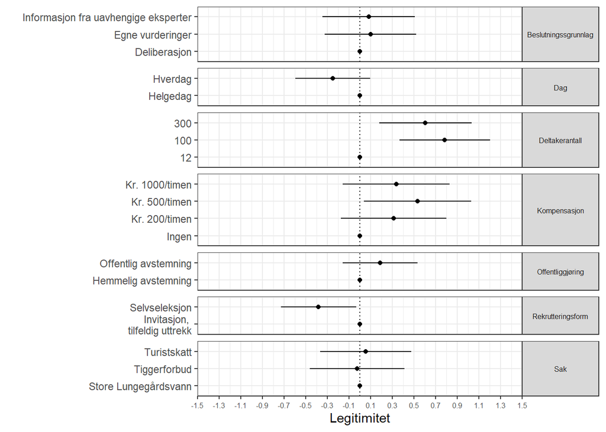

```r
source("C:/Users/svein/Documents/DemovateR/Surveys/amce.R")

main_01 <-  d %>% select(IntervjuID,
                         starts_with('R1DEMOVATE7') & ends_with('1')) %>%
  rename_at(vars(ends_with("1")),
            funs(str_replace(., "R1", ""))) %>%
  rename_at(vars(ends_with("1")),
                                 funs(str_replace(., "1", "")))
main_02 <-  d %>% select(IntervjuID,
                         starts_with('R1DEMOVATE7') & ends_with('2'))  %>%
  rename_at(vars(ends_with("2")),
            funs(str_replace(., "R1", ""))) %>%
  rename_at(vars(ends_with("2")),
                                 funs(str_replace(., "2", "")))
main_03 <-  d %>% select(IntervjuID,
                         starts_with('R1DEMOVATE7') & ends_with('3'))   %>%
  rename_at(vars(ends_with("3")),
            funs(str_replace(., "R1", ""))) %>%
  rename_at(vars(ends_with("3")),
                                 funs(str_replace(., "3", "")))

main <- bind_rows(main_01, main_02, main_03)


main <- main %>% mutate(DEMOVATE7_Antall = case_when(DEMOVATE7_Antall == 1 ~ '12',
                                                     DEMOVATE7_Antall == 2 ~ '100',
                                                     DEMOVATE7_Antall == 3 ~ '300',),
                        DEMOVATE7_Antall = lvls_reorder(DEMOVATE7_Antall, c(2,1,3)),
                        DEMOVATE7_Dag = case_when(DEMOVATE7_Dag == 1 ~ 'Hverdag',
                                                  DEMOVATE7_Dag == 2 ~ 'Helgedag'),
                        DEMOVATE7_Rekr = case_when(DEMOVATE7_Rekr == 1 ~ 'Selvseleksjon',
                                                   DEMOVATE7_Rekr == 2 ~ 'Invitasjon, \n tilfeldig uttrekk'),
                        DEMOVATE7_Komp = case_when(DEMOVATE7_Komp== 1 ~ 'Ingen',
                                                   DEMOVATE7_Komp == 2 ~ 'Kr. 200/timen',
                                                   DEMOVATE7_Komp == 3 ~ 'Kr. 500/timen',
                                                   DEMOVATE7_Komp == 4 ~ 'Kr. 1000/timen'),
                        DEMOVATE7_Komp = lvls_reorder(DEMOVATE7_Komp, c(1, 3, 4, 2)),
                        DEMOVATE7_Sak = case_when(DEMOVATE7_Sak == 1 ~ 'Store Lungegårdsvann',
                                                  DEMOVATE7_Sak == 2 ~ 'Tiggerforbud',
                                                  DEMOVATE7_Sak == 3 ~ 'Turistskatt'),
                        DEMOVATE7_Grunnlag = case_when(DEMOVATE7_Grunnlag == 1 ~ 'Egne vurderinger',
                                                       DEMOVATE7_Grunnlag == 2 ~ 'Informasjon fra uavhengige eksperter',
                                                       DEMOVATE7_Grunnlag == 3 ~ 'Deliberasjon'),
                        DEMOVATE7_Offentlig = case_when(DEMOVATE7_Offentlig == 1 ~ 'Offentlig avstemning',
                                                        DEMOVATE7_Offentlig == 2 ~ 'Hemmelig avstemning')
                        )

res_main <-  main %>%
  amce(DEMOVATE7_, DEMOVATE7_Antall, DEMOVATE7_Dag, DEMOVATE7_Rekr, DEMOVATE7_Komp, DEMOVATE7_Sak, DEMOVATE7_Grunnlag, DEMOVATE7_Offentlig)

res_main <- res_main %>%
  mutate(
  treatment =  case_when(treatment == "DEMOVATE7_Antall" ~ "Deltakerantall",
            treatment == "DEMOVATE7_Dag" ~ "Dag",
            treatment == "DEMOVATE7_Rekr" ~ "Rekrutteringsform",
            treatment == "DEMOVATE7_Komp" ~ "Kompensasjon",
            treatment == "DEMOVATE7_Sak" ~ "Sak",
            treatment == "DEMOVATE7_Grunnlag" ~ "Beslutningssgrunnlag",
            treatment == "DEMOVATE7_Offentlig" ~ "Offentliggjøring"))

fig_amce <-
  res_main %>%
  ggplot(aes(x = estimate, y = value)) +
  facet_grid(
    treatment ~ .,
    scales = "free_y",
    space = "free_y") +
  geom_errorbarh(
    aes(xmin = estimate - (2 * std_error),
        xmax = estimate + (2 * std_error)),
    height = 0) +
  geom_point() +
  geom_vline(aes(xintercept = 0), linetype = "dotted") +
  scale_x_continuous(
    limits = c(-1.5, 1.5),
    breaks = round(seq(-1.5, 1.5, 0.2), 2),
    expand = c(0, 0)) +
    labs(
    x = "Legitimitet",
    y = "") +
  theme_bw() +
  theme(plot.margin = unit(c(2, 2, 2, 2), "mm"),  plot.title = element_text(size=9), plot.subtitle = element_text(size=8), strip.text.y = element_text(size=6, angle=0) ,      axis.text.x=element_text(size=rel(0.7)))
fig_amce
```

Eksperimentet viser at respondentene er klart mer villig til å vektlegge et borgerpanel med et tresifret antall deltakere enn hvis det bare er 12 stykker. Det samme gjelder borgerpaneler som benytter seg av tilfeldig uttrekk. Disse to resultatene peker i retning av at folk er opptatt av at borgerpanelene skal være representative for innbyggernes syn.

# 2 Byborgerpanel - Norsk medborgerpanel 2020

Den andre studien følger opp den første med et tilnærmet identisk eksperiment. Forskjellen er at vi ikke tar med hvilke saker som skal diskuteres, da sakene som var aktuelle i den bergenske konteksten ikke ville være like aktuelle for innbyggerne i alle andre kommuner i Norge. I stedet tar vi inn en ny variabel som informerer om varigheten av arrangementet.

I tillegg er den avhengige variabelen om deltakelse endret fra prosent sannsynlighet til en 0-10-punktskala, hvor 0 er lik ‘Jeg ville helt sikkert ikke deltatt’ og 10 er lik ‘Jeg ville helt sikkert deltatt’.

## 2.1 Deltakelse

Vi ønsker nå å høre din mening om bruken av såkalte borgerpaneler i norske kommuner. Dette er en ordning hvor en gruppe innbyggere i kommunen blir invitert til å diskutere og gjøre seg opp en mening om en politisk sak. Vi legger nå fram en måte borgerpanelet kan gjennomføres på, og ber deg ta stilling til om du ville ha deltatt om det ble gjennomført slik vi beskriver: Borgerpanelet består av [12/ 100/ 300] deltakere, finner sted i sentrum av din kommune på en [hverdag/ helgedag], og varer i [en halv dag/ en dag/ to dager]. Deltakerne blir [ikke kompensert økonomisk/ kompensert med 200 kroner per time/ kompensert med 500 kroner per time/ kompensert med 1000 kroner per time] for å være med. [Registrering er åpen for alle innbyggerne i kommunen til det er fullt./ Deltakerne trekkes tilfeldig blant alle innbyggerne i kommunen.] Saken som skal diskuteres er et større boligprosjekt i kommunen. Deltakerne bestemmer seg ut fra [egne vurderinger og preferanser/ troverdig informasjon fra uavhengige eksperter/ meningsutveksling mellom deltakerne i mindre grupper, hvor diskusjonen ledes av uavhengige møteledere]. Deltakerne stemmer så over saken, og resultatet blir formidlet til kommunens politikere. [Hvem som deltok i borgerpanelet og hvordan de stemte vil være offentlig/ Hvem som deltok i borgerpanelet og hvordan de stemte vil ikke være offentlig].

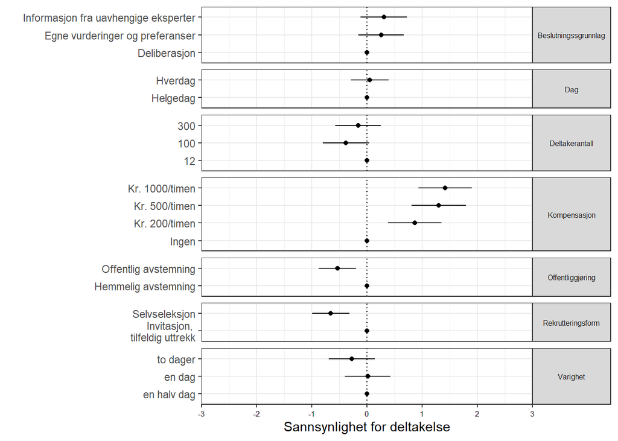

```r
# Hvor sannsynlig er det at du ville ha deltatt i et borgerpanel?

source("C:/Users/svein/Documents/DemovateR/Surveys/amce.R")

main <- d2 %>% mutate(r18padprolegran1 = case_when(r18padprolegran1 == 1 ~ '12',
                                                     r18padprolegran1 == 2 ~ '100',
                                                     r18padprolegran1 == 3 ~ '300',),
                      r18padprolegran1 = lvls_reorder(r18padprolegran1, c(2,1,3)),
                        r18padprolegran2 = case_when(r18padprolegran2 == 1 ~ 'Hverdag',
                                                  r18padprolegran2 == 2 ~ 'Helgedag'),
                        r18padprolegran3 = case_when(r18padprolegran3 == 1 ~ 'en halv dag',
                                                     r18padprolegran3 == 2 ~ 'en dag',
                                                     r18padprolegran3 == 3 ~ 'to dager'),
                      r18padprolegran3 = lvls_reorder(r18padprolegran3, c(2, 1, 3)),
                        r18padprolegran5 = case_when(r18padprolegran5 == 1 ~ 'Selvseleksjon',
                                                   r18padprolegran5 == 2 ~ 'Invitasjon, \n tilfeldig uttrekk'),
                        r18padprolegran4 = case_when(r18padprolegran4 == 1 ~ 'Ingen',
                                                   r18padprolegran4 == 2 ~ 'Kr. 200/timen',
                                                   r18padprolegran4 == 3 ~ 'Kr. 500/timen',
                                                   r18padprolegran4 == 4 ~ 'Kr. 1000/timen'),
                      r18padprolegran4 = lvls_reorder(r18padprolegran4, c(1, 3, 4, 2)),
                       r18padprolegran6 = case_when(r18padprolegran6 == 1 ~ 'Egne vurderinger og preferanser',
                                                       r18padprolegran6 == 2 ~ 'Informasjon fra uavhengige eksperter',
                                                       r18padprolegran6 == 3 ~ 'Deliberasjon'),
                        r18padprolegran7 = case_when(r18padprolegran7 == 1 ~ 'Offentlig avstemning',
                                                        r18padprolegran7 == 2 ~ 'Hemmelig avstemning')
                        )

res_main <-  main %>%
  amce(r18padproleg1, r18padprolegran1, r18padprolegran2, r18padprolegran3, r18padprolegran4, r18padprolegran5, r18padprolegran6, r18padprolegran7)

res_main <- res_main %>%
  mutate(
  treatment =  case_when(treatment == "r18padprolegran1" ~ "Deltakerantall",
            treatment == "r18padprolegran2" ~ "Dag",
            treatment == "r18padprolegran3" ~ "Varighet",
            treatment == "r18padprolegran4" ~ "Kompensasjon",
            treatment == "r18padprolegran5" ~ "Rekrutteringsform",
            treatment == "r18padprolegran6" ~ "Beslutningssgrunnlag",
            treatment == "r18padprolegran7" ~ "Offentliggjøring"))

fig_amce <-
  res_main %>%
  ggplot(aes(x = estimate, y = value)) +
  facet_grid(
    treatment ~ .,
    scales = "free_y",
    space = "free_y") +
  geom_errorbarh(
    aes(xmin = estimate - (2 * std_error),
        xmax = estimate + (2 * std_error)),
    height = 0) +
  geom_point() +
  geom_vline(aes(xintercept = 0), linetype = "dotted") +
  scale_x_continuous(
    limits = c(-3, 3),
    breaks = round(seq(-3, 3, 0.2), 0.2),
    expand = c(0, 0)) +
    labs(
    x = "Sannsynlighet for deltakelse",
    y = "") +
  theme_bw() +
  theme(plot.margin = unit(c(2, 2, 2, 2), "mm"),  plot.title = element_text(size=9), plot.subtitle = element_text(size=8), strip.text.y = element_text(size=6, angle=0) ,      axis.text.x=element_text(size=rel(0.7)))
fig_amce
```

## 2.2 Legitimitet

Hvor mye mener du resultatet fra borgerpanelet skal vektlegges når politikerne skal fatte den endelige beslutningen i saken? Respondentene svarer på en skala fra 0 til 10, hvor 0 betyr at resultatet ikke skal vektlegges i det hele tatt, og 10 betyr at resultatet må følges uansett.

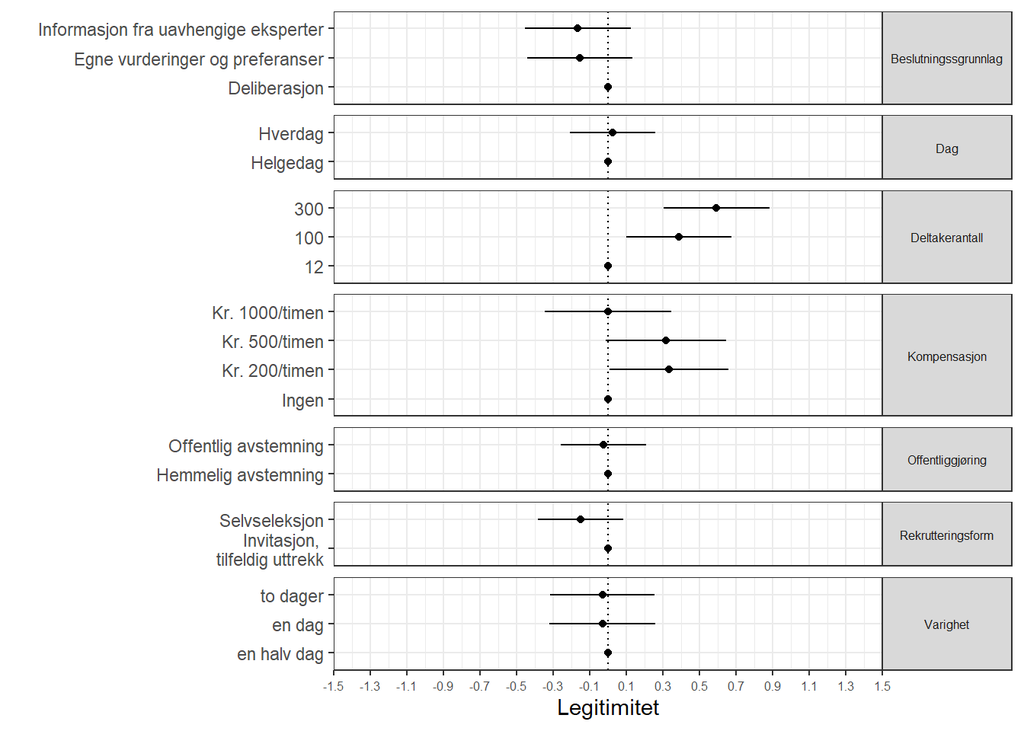

```r
# Distribusjon avhengig variabel

res_main <-  main %>%
  amce(r18padproleg2, r18padprolegran1, r18padprolegran2, r18padprolegran3, r18padprolegran4, r18padprolegran5, r18padprolegran6, r18padprolegran7)

res_main <- res_main %>%
  mutate(
  treatment =  case_when(treatment == "r18padprolegran1" ~ "Deltakerantall",
            treatment == "r18padprolegran2" ~ "Dag",
            treatment == "r18padprolegran3" ~ "Varighet",
            treatment == "r18padprolegran4" ~ "Kompensasjon",
            treatment == "r18padprolegran5" ~ "Rekrutteringsform",
            treatment == "r18padprolegran6" ~ "Beslutningssgrunnlag",
            treatment == "r18padprolegran7" ~ "Offentliggjøring"))

fig_amce <-
  res_main %>%
  ggplot(aes(x = estimate, y = value)) +
  facet_grid(
    treatment ~ .,
    scales = "free_y",
    space = "free_y") +
  geom_errorbarh(
    aes(xmin = estimate - (2 * std_error),
        xmax = estimate + (2 * std_error)),
    height = 0) +
  geom_point() +
  geom_vline(aes(xintercept = 0), linetype = "dotted") +
  scale_x_continuous(
    limits = c(-1.5, 1.5),
    breaks = round(seq(-1.5, 1.5, 0.2), 2),
    expand = c(0, 0)) +
    labs(
    x = "Legitimitet",
    y = "") +
  theme_bw() +
  theme(plot.margin = unit(c(2, 2, 2, 2), "mm"),  plot.title = element_text(size=9), plot.subtitle = element_text(size=8), strip.text.y = element_text(size=6, angle=0) ,      axis.text.x=element_text(size=rel(0.7)))
fig_amce
```